# Life and Time - PxVx - Base Model Comparisons

jflournoy

Mon Apr 18 10:31:35 2016

# Intro

**Template for model comparisons:**

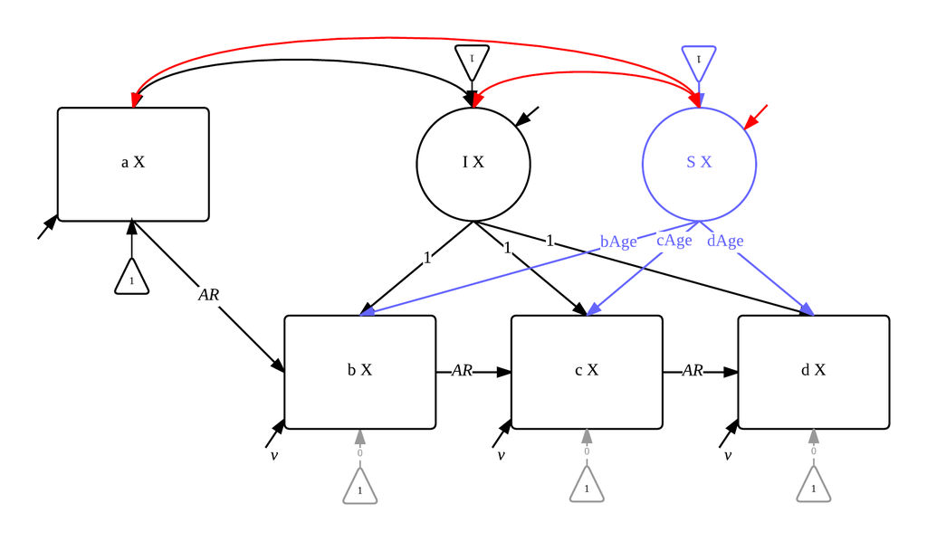

The above diagram captures all 3 models we wish to compare. The black portion is the base, intercept-only ALT model (**AR_Int**). We estimate 7 parameters: the initial status (`a X`) variance and mean, the autoregressive parameter constrained to be equal between all four waves (`AR`), the residual variances for waves 2-4 constrained to be equal (`v`), and a latent intercept mean, variance, and covariance with initial status.

The blue portion shows the addition of one parameter to capture the mean of a latent slope (`S X`), which gives us the **AR_LinM** model below. Finally, the red portion shows the addition of three parameters: the latent slope variance, and covariance with the latent intercept, and initial status (**AR_Lin** below).

# Comparisons

The below tables test fit improvements between these three models. Because we use the `tscores` command in MPlus, the MLR estimator is used, which requires an adjustment to the -2*Log Likelhood values before their difference is computed. For more information on this adjustment, see the [MPlus website](https://www.statmodel.com/chidiff.shtml) or the UCLA website. The *p*-values are calculated for the adjusted -2*LL difference with *df* equal to the difference in number of parameters estimated.

## All fit info

College Sample, aspfin

| Model 1 | Model 2 | LL M1 | LL M2 | AIC M1 | AIC M2 | BIC M1 | BIC M2 | Prms M1 | Prms M2 | -2*LL $\Delta$ | *df* | *p* |
| --- | --- | --- | --- | --- | --- | --- | --- | --- | --- | --- | --- | --- |
| AR_Int | AR_LinM | -3475.36 | -3475.29 | 6964.71 | 6966.58 | 6990.05 | 6995.54 | 7 | 8 | 0.13 | 1 | 0.72 |
| AR_LinM | AR_Lin | -3475.29 | -3469.82 | 6966.58 | 6961.65 | 6995.54 | 7001.47 | 8 | 11 | 35.97 | 3 | 0.00 |

College Sample, BFA_AC

| Model 1 | Model 2 | LL M1 | LL M2 | AIC M1 | AIC M2 | BIC M1 | BIC M2 | Prms M1 | Prms M2 | -2*LL $\Delta$ | *df* | *p* |
| --- | --- | --- | --- | --- | --- | --- | --- | --- | --- | --- | --- | --- |
| AR_Int | AR_LinM | -3108.52 | -3108.44 | 6231.05 | 6232.87 | 6256.42 | 6261.86 | 7 | 8 | 0.17 | 1 | 0.68 |
| AR_LinM | AR_Lin | -3108.44 | -3107.69 | 6232.87 | 6237.38 | 6261.86 | 6277.24 | 8 | 11 | 1.78 | 3 | 0.62 |

College Sample, BFA_AP

| Model 1 | Model 2 | LL M1 | LL M2 | AIC M1 | AIC M2 | BIC M1 | BIC M2 | Prms M1 | Prms M2 | -2*LL $\Delta$ | *df* | *p* |
| --- | --- | --- | --- | --- | --- | --- | --- | --- | --- | --- | --- | --- |
| AR_Int | AR_LinM | -3130.58 | -3130.38 | 6275.17 | 6276.75 | 6300.53 | 6305.74 | 7 | 8 | 0.47 | 1 | 0.49 |
| AR_LinM | AR_Lin | -3130.38 | -3129.97 | 6276.75 | 6281.95 | 6305.74 | 6321.81 | 8 | 11 | 0.65 | 3 | 0.89 |

College Sample, BFA_CI

| Model 1 | Model 2 | LL M1 | LL M2 | AIC M1 | AIC M2 | BIC M1 | BIC M2 | Prms M1 | Prms M2 | -2*LL $\Delta$ | *df* | *p* |
| --- | --- | --- | --- | --- | --- | --- | --- | --- | --- | --- | --- | --- |
| AR_Int | AR_LinM | -3240.49 | -3239.97 | 6494.98 | 6495.95 | 6520.34 | 6524.94 | 7 | 8 | 0.90 | 1 | 0.34 |
| AR_LinM | AR_Lin | -3239.97 | -3237.59 | 6495.95 | 6497.18 | 6524.94 | 6537.05 | 8 | 11 | 5.19 | 3 | 0.16 |

College Sample, BFA_CO

| Model 1 | Model 2 | LL M1 | LL M2 | AIC M1 | AIC M2 | BIC M1 | BIC M2 | Prms M1 | Prms M2 | -2*LL $\Delta$ | *df* | *p* |
| --- | --- | --- | --- | --- | --- | --- | --- | --- | --- | --- | --- | --- |
| AR_Int | AR_LinM | -3210.23 | -3210.15 | 6434.46 | 6436.29 | 6459.80 | 6465.26 | 7 | 8 | 0.15 | 1 | 0.70 |
| AR_LinM | AR_Lin | -3210.15 | -3209.39 | 6436.29 | 6440.78 | 6465.26 | 6480.60 | 8 | 11 | 1.94 | 3 | 0.58 |

College Sample, BFA_EA

| Model 1 | Model 2 | LL M1 | LL M2 | AIC M1 | AIC M2 | BIC M1 | BIC M2 | Prms M1 | Prms M2 | -2*LL $\Delta$ | *df* | *p* |
| --- | --- | --- | --- | --- | --- | --- | --- | --- | --- | --- | --- | --- |
| AR_Int | AR_LinM | -3177.82 | -3176.76 | 6369.65 | 6369.53 | 6394.99 | 6398.49 | 7 | 8 | 1.88 | 1 | 0.17 |
| AR_LinM | AR_Lin | -3176.76 | -3169.66 | 6369.53 | 6361.31 | 6398.49 | 6401.13 | 8 | 11 | 26.17 | 3 | 0.00 |

College Sample, BFA_EE

| Model 1 | Model 2 | LL M1 | LL M2 | AIC M1 | AIC M2 | BIC M1 | BIC M2 | Prms M1 | Prms M2 | -2*LL $\Delta$ | *df* | *p* |
| --- | --- | --- | --- | --- | --- | --- | --- | --- | --- | --- | --- | --- |
| AR_Int | AR_LinM | -3210.97 | -3210.49 | 6435.94 | 6436.98 | 6461.31 | 6465.98 | 7 | 8 | 1.00 | 1 | 0.32 |
| AR_LinM | AR_Lin | -3210.49 | -3210.76 | 6436.98 | 6443.52 | 6465.98 | 6483.39 | 8 | 11 | -0.39 | 3 | 1.00 |

College Sample, BFA_MT

| Model 1 | Model 2 | LL M1 | LL M2 | AIC M1 | AIC M2 | BIC M1 | BIC M2 | Prms M1 | Prms M2 | -2*LL $\Delta$ | *df* | *p* |
| --- | --- | --- | --- | --- | --- | --- | --- | --- | --- | --- | --- | --- |
| AR_Int | AR_LinM | -3128.78 | -3128.35 | 6271.56 | 6272.71 | 6296.93 | 6301.70 | 7 | 8 | 1.04 | 1 | 0.31 |
| AR_LinM | AR_Lin | -3128.35 | -3128.94 | 6272.71 | 6279.88 | 6301.70 | 6319.74 | 8 | 11 | -0.55 | 3 | 1.00 |

College Sample, BFA_NV

| Model 1 | Model 2 | LL M1 | LL M2 | AIC M1 | AIC M2 | BIC M1 | BIC M2 | Prms M1 | Prms M2 | -2*LL $\Delta$ | *df* | *p* |
| --- | --- | --- | --- | --- | --- | --- | --- | --- | --- | --- | --- | --- |
| AR_Int | AR_LinM | -3468.61 | -3468.57 | 6951.23 | 6953.14 | 6976.60 | 6982.13 | 7 | 8 | 0.09 | 1 | 0.76 |
| AR_LinM | AR_Lin | -3468.57 | -3468.35 | 6953.14 | 6958.71 | 6982.13 | 6998.57 | 8 | 11 | 0.59 | 3 | 0.90 |

College Sample, BFA_NW

| Model 1 | Model 2 | LL M1 | LL M2 | AIC M1 | AIC M2 | BIC M1 | BIC M2 | Prms M1 | Prms M2 | -2*LL $\Delta$ | *df* | *p* |
| --- | --- | --- | --- | --- | --- | --- | --- | --- | --- | --- | --- | --- |
| AR_Int | AR_LinM | -3299.55 | -3299.39 | 6613.09 | 6614.77 | 6638.44 | 6643.73 | 7 | 8 | 0.33 | 1 | 0.57 |
| AR_LinM | AR_Lin | -3299.39 | -3298.81 | 6614.77 | 6619.62 | 6643.73 | 6659.44 | 8 | 11 | 1.39 | 3 | 0.71 |

College Sample, BFA_OI

| Model 1 | Model 2 | LL M1 | LL M2 | AIC M1 | AIC M2 | BIC M1 | BIC M2 | Prms M1 | Prms M2 | -2*LL $\Delta$ | *df* | *p* |
| --- | --- | --- | --- | --- | --- | --- | --- | --- | --- | --- | --- | --- |
| AR_Int | AR_LinM | -3069.73 | -3067.55 | 6153.46 | 6151.10 | 6178.83 | 6180.09 | 7 | 8 | 4.44 | 1 | 0.04 |
| AR_LinM | AR_Lin | -3067.55 | -3068.08 | 6151.10 | 6158.16 | 6180.09 | 6198.02 | 8 | 11 | -1.16 | 3 | 1.00 |

College Sample, BFA_OO

| Model 1 | Model 2 | LL M1 | LL M2 | AIC M1 | AIC M2 | BIC M1 | BIC M2 | Prms M1 | Prms M2 | -2*LL $\Delta$ | *df* | *p* |
| --- | --- | --- | --- | --- | --- | --- | --- | --- | --- | --- | --- | --- |
| AR_Int | AR_LinM | -3058.61 | -3057.01 | 6131.22 | 6130.01 | 6156.56 | 6158.97 | 7 | 8 | 3.06 | 1 | 0.08 |
| AR_LinM | AR_Lin | -3057.01 | -3051.27 | 6130.01 | 6124.54 | 6158.97 | 6164.37 | 8 | 11 | 9.94 | 3 | 0.02 |

College Sample, BFI_A6

| Model 1 | Model 2 | LL M1 | LL M2 | AIC M1 | AIC M2 | BIC M1 | BIC M2 | Prms M1 | Prms M2 | -2*LL $\Delta$ | *df* | *p* |
| --- | --- | --- | --- | --- | --- | --- | --- | --- | --- | --- | --- | --- |
| AR_Int | AR_LinM | -3251.42 | -3247.74 | 6516.83 | 6511.49 | 6542.20 | 6540.48 | 7 | 8 | 8.37 | 1 | 0.00 |
| AR_LinM | AR_Lin | -3247.74 | -3244.10 | 6511.49 | 6510.21 | 6540.48 | 6550.07 | 8 | 11 | 10.03 | 3 | 0.02 |

College Sample, BFI_C

| Model 1 | Model 2 | LL M1 | LL M2 | AIC M1 | AIC M2 | BIC M1 | BIC M2 | Prms M1 | Prms M2 | -2*LL $\Delta$ | *df* | *p* |
| --- | --- | --- | --- | --- | --- | --- | --- | --- | --- | --- | --- | --- |
| AR_Int | AR_LinM | -3169.57 | -3168.93 | 6353.14 | 6353.86 | 6378.51 | 6382.86 | 7 | 8 | 1.17 | 1 | 0.28 |
| AR_LinM | AR_Lin | -3168.93 | -3167.68 | 6353.86 | 6357.36 | 6382.86 | 6397.23 | 8 | 11 | 1.72 | 3 | 0.63 |

College Sample, BFI_E

| Model 1 | Model 2 | LL M1 | LL M2 | AIC M1 | AIC M2 | BIC M1 | BIC M2 | Prms M1 | Prms M2 | -2*LL $\Delta$ | *df* | *p* |
| --- | --- | --- | --- | --- | --- | --- | --- | --- | --- | --- | --- | --- |
| AR_Int | AR_LinM | -3281.03 | -3279.40 | 6576.06 | 6574.80 | 6601.42 | 6603.79 | 7 | 8 | 3.48 | 1 | 0.06 |
| AR_LinM | AR_Lin | -3279.40 | -3279.72 | 6574.80 | 6581.44 | 6603.79 | 6621.31 | 8 | 11 | -0.82 | 3 | 1.00 |

College Sample, bfi_hp8

| Model 1 | Model 2 | LL M1 | LL M2 | AIC M1 | AIC M2 | BIC M1 | BIC M2 | Prms M1 | Prms M2 | -2*LL $\Delta$ | *df* | *p* |
| --- | --- | --- | --- | --- | --- | --- | --- | --- | --- | --- | --- | --- |
| AR_Int | AR_LinM | -3161.67 | -3159.45 | 6337.34 | 6334.89 | 6362.71 | 6363.88 | 7 | 8 | NA | 1 | NA |
| AR_LinM | AR_Lin | -3159.45 | -3157.53 | 6334.89 | 6337.06 | 6363.88 | 6376.93 | 8 | 11 | NA | 3 | NA |

College Sample, BFI_N

| Model 1 | Model 2 | LL M1 | LL M2 | AIC M1 | AIC M2 | BIC M1 | BIC M2 | Prms M1 | Prms M2 | -2*LL $\Delta$ | *df* | *p* |
| --- | --- | --- | --- | --- | --- | --- | --- | --- | --- | --- | --- | --- |
| AR_Int | AR_LinM | -3369.02 | -3367.90 | 6752.03 | 6751.80 | 6777.4 | 6780.80 | 7 | 8 | 2.03 | 1 | 0.15 |
| AR_LinM | AR_Lin | -3367.90 | -3365.66 | 6751.80 | 6753.32 | 6780.8 | 6793.19 | 8 | 11 | 5.18 | 3 | 0.16 |

College Sample, BFI_O

| Model 1 | Model 2 | LL M1 | LL M2 | AIC M1 | AIC M2 | BIC M1 | BIC M2 | Prms M1 | Prms M2 | -2*LL $\Delta$ | *df* | *p* |
| --- | --- | --- | --- | --- | --- | --- | --- | --- | --- | --- | --- | --- |
| AR_Int | AR_LinM | -3068.35 | -3064.09 | 6150.70 | 6144.18 | 6176.07 | 6173.17 | 7 | 8 | 8.51 | 1 | 0.00 |
| AR_LinM | AR_Lin | -3064.09 | -3057.78 | 6144.18 | 6137.55 | 6173.17 | 6177.42 | 8 | 11 | 12.32 | 3 | 0.01 |

College Sample, D_SCALE

| Model 1 | Model 2 | LL M1 | LL M2 | AIC M1 | AIC M2 | BIC M1 | BIC M2 | Prms M1 | Prms M2 | -2*LL $\Delta$ | *df* | *p* |
| --- | --- | --- | --- | --- | --- | --- | --- | --- | --- | --- | --- | --- |
| AR_Int | AR_LinM | -3115.10 | -3111.45 | 6244.20 | 6238.89 | 6269.57 | 6267.88 | 7 | 8 | 7.57 | 1 | 0.01 |
| AR_LinM | AR_Lin | -3111.45 | -3110.67 | 6238.89 | 6243.35 | 6267.88 | 6283.21 | 8 | 11 | 1.33 | 3 | 0.72 |

College Sample, HRZ_COL

| Model 1 | Model 2 | LL M1 | LL M2 | AIC M1 | AIC M2 | BIC M1 | BIC M2 | Prms M1 | Prms M2 | -2*LL $\Delta$ | *df* | *p* |
| --- | --- | --- | --- | --- | --- | --- | --- | --- | --- | --- | --- | --- |
| AR_Int | AR_LinM | -3137.23 | -3137.12 | 6288.46 | 6290.24 | 6313.78 | 6319.18 | 7 | 8 | 0.20 | 1 | 0.65 |
| AR_LinM | AR_Lin | -3137.12 | -3135.50 | 6290.24 | 6293.00 | 6319.18 | 6332.78 | 8 | 11 | 3.63 | 3 | 0.30 |

College Sample, HRZ_IND

| Model 1 | Model 2 | LL M1 | LL M2 | AIC M1 | AIC M2 | BIC M1 | BIC M2 | Prms M1 | Prms M2 | -2*LL $\Delta$ | *df* | *p* |
| --- | --- | --- | --- | --- | --- | --- | --- | --- | --- | --- | --- | --- |
| AR_Int | AR_LinM | -3239.97 | -3238.99 | 6493.95 | 6493.98 | 6519.26 | 6522.91 | 7 | 8 | 2.04 | 1 | 0.15 |
| AR_LinM | AR_Lin | -3238.99 | -3238.61 | 6493.98 | 6499.22 | 6522.91 | 6539.01 | 8 | 11 | 1.05 | 3 | 0.79 |

College Sample, MVI_POMP

| Model 1 | Model 2 | LL M1 | LL M2 | AIC M1 | AIC M2 | BIC M1 | BIC M2 | Prms M1 | Prms M2 | -2*LL $\Delta$ | *df* | *p* |
| --- | --- | --- | --- | --- | --- | --- | --- | --- | --- | --- | --- | --- |
| AR_Int | AR_LinM | -2653.46 | -2653.41 | 5320.93 | 5322.83 | 5346.27 | 5351.79 | 7 | 8 | 0.09 | 1 | 0.76 |
| AR_LinM | AR_Lin | -2653.41 | -2650.64 | 5322.83 | 5323.28 | 5351.79 | 5363.10 | 8 | 11 | 6.16 | 3 | 0.10 |

College Sample, S_SCALE

| Model 1 | Model 2 | LL M1 | LL M2 | AIC M1 | AIC M2 | BIC M1 | BIC M2 | Prms M1 | Prms M2 | -2*LL $\Delta$ | *df* | *p* |
| --- | --- | --- | --- | --- | --- | --- | --- | --- | --- | --- | --- | --- |
| AR_Int | AR_LinM | -3006.29 | -3005.54 | 6026.57 | 6027.07 | 6051.94 | 6056.06 | 7 | 8 | 1.35 | 1 | 0.25 |
| AR_LinM | AR_Lin | -3005.54 | -3001.14 | 6027.07 | 6024.27 | 6056.06 | 6064.14 | 8 | 11 | 12.61 | 3 | 0.01 |

College Sample, USI

| Model 1 | Model 2 | LL M1 | LL M2 | AIC M1 | AIC M2 | BIC M1 | BIC M2 | Prms M1 | Prms M2 | -2*LL $\Delta$ | *df* | *p* |
| --- | --- | --- | --- | --- | --- | --- | --- | --- | --- | --- | --- | --- |
| AR_Int | AR_LinM | -3168.67 | -3168.42 | 6351.35 | 6352.83 | 6376.66 | 6381.77 | 7 | 8 | 0.42 | 1 | 0.52 |
| AR_LinM | AR_Lin | -3168.42 | -3167.62 | 6352.83 | 6357.23 | 6381.77 | 6397.02 | 8 | 11 | 3.41 | 3 | 0.33 |

College Sample, VRT_COL

| Model 1 | Model 2 | LL M1 | LL M2 | AIC M1 | AIC M2 | BIC M1 | BIC M2 | Prms M1 | Prms M2 | -2*LL $\Delta$ | *df* | *p* |
| --- | --- | --- | --- | --- | --- | --- | --- | --- | --- | --- | --- | --- |
| AR_Int | AR_LinM | -3328.83 | -3327.98 | 6671.67 | 6671.95 | 6696.98 | 6700.89 | 7 | 8 | 1.52 | 1 | 0.22 |
| AR_LinM | AR_Lin | -3327.98 | -3326.83 | 6671.95 | 6675.66 | 6700.89 | 6715.44 | 8 | 11 | 2.70 | 3 | 0.44 |

College Sample, VRT_IND

| Model 1 | Model 2 | LL M1 | LL M2 | AIC M1 | AIC M2 | BIC M1 | BIC M2 | Prms M1 | Prms M2 | -2*LL $\Delta$ | *df* | *p* |
| --- | --- | --- | --- | --- | --- | --- | --- | --- | --- | --- | --- | --- |
| AR_Int | AR_LinM | -3375.26 | -3375.26 | 6764.52 | 6766.52 | 6789.84 | 6795.45 | 7 | 8 | 0.01 | 1 | 0.92 |
| AR_LinM | AR_Lin | -3375.26 | -3373.07 | 6766.52 | 6768.14 | 6795.45 | 6807.93 | 8 | 11 | 6.71 | 3 | 0.08 |

Informant Sample, I_A

| Model 1 | Model 2 | LL M1 | LL M2 | AIC M1 | AIC M2 | BIC M1 | BIC M2 | Prms M1 | Prms M2 | -2*LL $\Delta$ | *df* | *p* |
| --- | --- | --- | --- | --- | --- | --- | --- | --- | --- | --- | --- | --- |
| AR_Int | AR_LinM | -6570.86 | -6567.51 | 13155.72 | 13151.02 | 13186.48 | 13186.18 | 7 | 8 | 6.32 | 1 | 0.01 |
| AR_LinM | AR_Lin | -6567.51 | -6567.26 | 13151.02 | 13156.52 | 13186.18 | 13204.87 | 8 | 11 | 0.33 | 3 | 0.95 |

Informant Sample, I_C

| Model 1 | Model 2 | LL M1 | LL M2 | AIC M1 | AIC M2 | BIC M1 | BIC M2 | Prms M1 | Prms M2 | -2*LL $\Delta$ | *df* | *p* |
| --- | --- | --- | --- | --- | --- | --- | --- | --- | --- | --- | --- | --- |
| AR_Int | AR_LinM | -6321.97 | -6317.94 | 12657.93 | 12651.87 | 12688.70 | 12687.03 | 7 | 8 | 7.88 | 1 | 0.0 |
| AR_LinM | AR_Lin | -6317.94 | -6317.48 | 12651.87 | 12656.97 | 12687.03 | 12705.32 | 8 | 11 | 0.58 | 3 | 0.9 |

Informant Sample, I_D

| Model 1 | Model 2 | LL M1 | LL M2 | AIC M1 | AIC M2 | BIC M1 | BIC M2 | Prms M1 | Prms M2 | -2*LL $\Delta$ | *df* | *p* |
| --- | --- | --- | --- | --- | --- | --- | --- | --- | --- | --- | --- | --- |
| AR_Int | AR_LinM | -6055.29 | -6054.18 | 12124.58 | 12124.36 | 12155.34 | 12159.53 | 7 | 8 | 2.14 | 1 | 0.14 |
| AR_LinM | AR_Lin | -6054.18 | -6054.23 | 12124.36 | 12130.46 | 12159.53 | 12178.80 | 8 | 11 | -0.08 | 3 | 1.00 |

Informant Sample, I_E

| Model 1 | Model 2 | LL M1 | LL M2 | AIC M1 | AIC M2 | BIC M1 | BIC M2 | Prms M1 | Prms M2 | -2*LL $\Delta$ | *df* | *p* |
| --- | --- | --- | --- | --- | --- | --- | --- | --- | --- | --- | --- | --- |
| AR_Int | AR_LinM | -6569.90 | -6567.01 | 13153.80 | 13150.03 | 13184.57 | 13185.19 | 7 | 8 | 4.74 | 1 | 0.03 |
| AR_LinM | AR_Lin | -6567.01 | -6567.34 | 13150.03 | 13156.68 | 13185.19 | 13205.02 | 8 | 11 | -0.47 | 3 | 1.00 |

Informant Sample, I_N

| Model 1 | Model 2 | LL M1 | LL M2 | AIC M1 | AIC M2 | BIC M1 | BIC M2 | Prms M1 | Prms M2 | -2*LL $\Delta$ | *df* | *p* |
| --- | --- | --- | --- | --- | --- | --- | --- | --- | --- | --- | --- | --- |
| AR_Int | AR_LinM | -6736.30 | -6734.73 | 13486.60 | 13485.47 | 13517.37 | 13520.63 | 7 | 8 | 3.84 | 1 | 0.05 |
| AR_LinM | AR_Lin | -6734.73 | -6735.15 | 13485.47 | 13492.31 | 13520.63 | 13540.66 | 8 | 11 | -0.70 | 3 | 1.00 |

Informant Sample, I_O

| Model 1 | Model 2 | LL M1 | LL M2 | AIC M1 | AIC M2 | BIC M1 | BIC M2 | Prms M1 | Prms M2 | -2*LL $\Delta$ | *df* | *p* |
| --- | --- | --- | --- | --- | --- | --- | --- | --- | --- | --- | --- | --- |
| AR_Int | AR_LinM | -6433.27 | -6432.99 | 12880.54 | 12881.98 | 12911.31 | 12917.14 | 7 | 8 | 0.54 | 1 | 0.46 |
| AR_LinM | AR_Lin | -6432.99 | -6431.37 | 12881.98 | 12884.74 | 12917.14 | 12933.08 | 8 | 11 | 3.32 | 3 | 0.34 |

Informant Sample, I_S

| Model 1 | Model 2 | LL M1 | LL M2 | AIC M1 | AIC M2 | BIC M1 | BIC M2 | Prms M1 | Prms M2 | -2*LL $\Delta$ | *df* | *p* |
| --- | --- | --- | --- | --- | --- | --- | --- | --- | --- | --- | --- | --- |
| AR_Int | AR_LinM | -6077.59 | -6074.05 | 12169.18 | 12164.09 | 12199.94 | 12199.26 | 7 | 8 | 6.98 | 1 | 0.01 |
| AR_LinM | AR_Lin | -6074.05 | -6074.48 | 12164.09 | 12170.95 | 12199.26 | 12219.30 | 8 | 11 | -0.49 | 3 | 1.00 |

National Sample, aspfin

| Model 1 | Model 2 | LL M1 | LL M2 | AIC M1 | AIC M2 | BIC M1 | BIC M2 | Prms M1 | Prms M2 | -2*LL $\Delta$ | *df* | *p* |
| --- | --- | --- | --- | --- | --- | --- | --- | --- | --- | --- | --- | --- |
| AR_Int | AR_LinM | -11043.95 | -11043.92 | 22101.89 | 22103.85 | 22135.21 | 22141.92 | 7 | 8 | 0.04 | 1 | 0.85 |
| AR_LinM | AR_Lin | -11043.92 | -11039.90 | 22103.85 | 22101.80 | 22141.92 | 22154.15 | 8 | 11 | 9.23 | 3 | 0.03 |

National Sample, BFA_AC

| Model 1 | Model 2 | LL M1 | LL M2 | AIC M1 | AIC M2 | BIC M1 | BIC M2 | Prms M1 | Prms M2 | -2*LL $\Delta$ | *df* | *p* |
| --- | --- | --- | --- | --- | --- | --- | --- | --- | --- | --- | --- | --- |
| AR_Int | AR_LinM | -10085.88 | -10084.93 | 20185.76 | 20185.86 | 20219.09 | 20223.94 | 7 | 8 | 1.85 | 1 | 0.17 |
| AR_LinM | AR_Lin | -10084.93 | -10074.58 | 20185.86 | 20171.15 | 20223.94 | 20223.52 | 8 | 11 | 14.10 | 3 | 0.00 |

National Sample, BFA_AP

| Model 1 | Model 2 | LL M1 | LL M2 | AIC M1 | AIC M2 | BIC M1 | BIC M2 | Prms M1 | Prms M2 | -2*LL $\Delta$ | *df* | *p* |
| --- | --- | --- | --- | --- | --- | --- | --- | --- | --- | --- | --- | --- |
| AR_Int | AR_LinM | -10051.03 | -10047.44 | 20116.05 | 20110.88 | 20149.38 | 20148.97 | 7 | 8 | 6.17 | 1 | 0.01 |
| AR_LinM | AR_Lin | -10047.44 | -10040.53 | 20110.88 | 20103.05 | 20148.97 | 20155.42 | 8 | 11 | 10.95 | 3 | 0.01 |

National Sample, BFA_CI

| Model 1 | Model 2 | LL M1 | LL M2 | AIC M1 | AIC M2 | BIC M1 | BIC M2 | Prms M1 | Prms M2 | -2*LL $\Delta$ | *df* | *p* |
| --- | --- | --- | --- | --- | --- | --- | --- | --- | --- | --- | --- | --- |
| AR_Int | AR_LinM | -10406.4 | -10403.00 | 20826.81 | 20821.99 | 20860.13 | 20860.07 | 7 | 8 | 6.97 | 1 | 0.01 |
| AR_LinM | AR_Lin | -10403.0 | -10399.87 | 20821.99 | 20821.74 | 20860.07 | 20874.10 | 8 | 11 | 4.14 | 3 | 0.25 |

National Sample, BFA_CO

| Model 1 | Model 2 | LL M1 | LL M2 | AIC M1 | AIC M2 | BIC M1 | BIC M2 | Prms M1 | Prms M2 | -2*LL $\Delta$ | *df* | *p* |
| --- | --- | --- | --- | --- | --- | --- | --- | --- | --- | --- | --- | --- |
| AR_Int | AR_LinM | -10095.89 | -10095.85 | 20205.78 | 20207.71 | 20239.11 | 20245.79 | 7 | 8 | 0.08 | 1 | 0.78 |
| AR_LinM | AR_Lin | -10095.85 | -10093.03 | 20207.71 | 20208.06 | 20245.79 | 20260.42 | 8 | 11 | 5.80 | 3 | 0.12 |

National Sample, BFA_EA

| Model 1 | Model 2 | LL M1 | LL M2 | AIC M1 | AIC M2 | BIC M1 | BIC M2 | Prms M1 | Prms M2 | -2*LL $\Delta$ | *df* | *p* |
| --- | --- | --- | --- | --- | --- | --- | --- | --- | --- | --- | --- | --- |
| AR_Int | AR_LinM | -10349.25 | -10349.25 | 20712.51 | 20714.51 | 20745.83 | 20752.59 | 7 | 8 | 0.00 | 1 | 0.94 |
| AR_LinM | AR_Lin | -10349.25 | -10344.05 | 20714.51 | 20710.10 | 20752.59 | 20762.46 | 8 | 11 | 8.66 | 3 | 0.03 |

National Sample, BFA_EE

| Model 1 | Model 2 | LL M1 | LL M2 | AIC M1 | AIC M2 | BIC M1 | BIC M2 | Prms M1 | Prms M2 | -2*LL $\Delta$ | *df* | *p* |
| --- | --- | --- | --- | --- | --- | --- | --- | --- | --- | --- | --- | --- |
| AR_Int | AR_LinM | -10343.95 | -10343.19 | 20701.90 | 20702.38 | 20735.22 | 20740.47 | 7 | 8 | 1.35 | 1 | 0.25 |
| AR_LinM | AR_Lin | -10343.19 | -10336.26 | 20702.38 | 20694.53 | 20740.47 | 20746.89 | 8 | 11 | 11.99 | 3 | 0.01 |

National Sample, BFA_MT

| Model 1 | Model 2 | LL M1 | LL M2 | AIC M1 | AIC M2 | BIC M1 | BIC M2 | Prms M1 | Prms M2 | -2*LL $\Delta$ | *df* | *p* |
| --- | --- | --- | --- | --- | --- | --- | --- | --- | --- | --- | --- | --- |
| AR_Int | AR_LinM | -9959.05 | -9958.67 | 19932.11 | 19933.34 | 19965.43 | 19971.42 | 7 | 8 | 0.66 | 1 | 0.42 |
| AR_LinM | AR_Lin | -9958.67 | -9946.95 | 19933.34 | 19915.90 | 19971.42 | 19968.27 | 8 | 11 | 18.13 | 3 | 0.00 |

National Sample, BFA_NV

| Model 1 | Model 2 | LL M1 | LL M2 | AIC M1 | AIC M2 | BIC M1 | BIC M2 | Prms M1 | Prms M2 | -2*LL $\Delta$ | *df* | *p* |
| --- | --- | --- | --- | --- | --- | --- | --- | --- | --- | --- | --- | --- |
| AR_Int | AR_LinM | -11099.87 | -11093.42 | 22213.73 | 22202.85 | 22247.06 | 22240.93 | 7 | 8 | 8.82 | 1 | 0.00 |
| AR_LinM | AR_Lin | -11093.42 | -11089.19 | 22202.85 | 22200.38 | 22240.93 | 22252.75 | 8 | 11 | 4.17 | 3 | 0.24 |

National Sample, BFA_NW

| Model 1 | Model 2 | LL M1 | LL M2 | AIC M1 | AIC M2 | BIC M1 | BIC M2 | Prms M1 | Prms M2 | -2*LL $\Delta$ | *df* | *p* |
| --- | --- | --- | --- | --- | --- | --- | --- | --- | --- | --- | --- | --- |
| AR_Int | AR_LinM | -10599.96 | -10597.46 | 21213.93 | 21210.92 | 21247.25 | 21249.00 | 7 | 8 | 6.14 | 1 | 0.01 |
| AR_LinM | AR_Lin | -10597.46 | -10596.64 | 21210.92 | 21215.28 | 21249.00 | 21267.65 | 8 | 11 | 1.07 | 3 | 0.78 |

National Sample, BFA_OI

| Model 1 | Model 2 | LL M1 | LL M2 | AIC M1 | AIC M2 | BIC M1 | BIC M2 | Prms M1 | Prms M2 | -2*LL $\Delta$ | *df* | *p* |
| --- | --- | --- | --- | --- | --- | --- | --- | --- | --- | --- | --- | --- |
| AR_Int | AR_LinM | -9981.59 | -9980.86 | 19977.18 | 19977.73 | 20010.50 | 20015.81 | 7 | 8 | 1.58 | 1 | 0.21 |
| AR_LinM | AR_Lin | -9980.86 | -9978.64 | 19977.73 | 19979.28 | 20015.81 | 20031.64 | 8 | 11 | 2.88 | 3 | 0.41 |

National Sample, BFA_OO

| Model 1 | Model 2 | LL M1 | LL M2 | AIC M1 | AIC M2 | BIC M1 | BIC M2 | Prms M1 | Prms M2 | -2*LL $\Delta$ | *df* | *p* |
| --- | --- | --- | --- | --- | --- | --- | --- | --- | --- | --- | --- | --- |
| AR_Int | AR_LinM | -9974.93 | -9974.75 | 19963.87 | 19965.51 | 19997.19 | 20003.59 | 7 | 8 | 0.34 | 1 | 0.56 |
| AR_LinM | AR_Lin | -9974.75 | -9969.68 | 19965.51 | 19961.35 | 20003.59 | 20013.72 | 8 | 11 | 7.22 | 3 | 0.07 |

National Sample, BFI_A6

| Model 1 | Model 2 | LL M1 | LL M2 | AIC M1 | AIC M2 | BIC M1 | BIC M2 | Prms M1 | Prms M2 | -2*LL $\Delta$ | *df* | *p* |
| --- | --- | --- | --- | --- | --- | --- | --- | --- | --- | --- | --- | --- |
| AR_Int | AR_LinM | -10526.92 | -10517.46 | 21067.84 | 21050.92 | 21101.16 | 21089.00 | 7 | 8 | 18.19 | 1 | 0.00 |
| AR_LinM | AR_Lin | -10517.46 | -10512.02 | 21050.92 | 21046.04 | 21089.00 | 21098.41 | 8 | 11 | 8.84 | 3 | 0.03 |

National Sample, BFI_C

| Model 1 | Model 2 | LL M1 | LL M2 | AIC M1 | AIC M2 | BIC M1 | BIC M2 | Prms M1 | Prms M2 | -2*LL $\Delta$ | *df* | *p* |
| --- | --- | --- | --- | --- | --- | --- | --- | --- | --- | --- | --- | --- |
| AR_Int | AR_LinM | -10253.89 | -10248.81 | 20521.78 | 20513.62 | 20555.11 | 20551.71 | 7 | 8 | 11.98 | 1 | 0.00 |
| AR_LinM | AR_Lin | -10248.81 | -10243.03 | 20513.62 | 20508.06 | 20551.71 | 20560.42 | 8 | 11 | 9.74 | 3 | 0.02 |

National Sample, BFI_E

| Model 1 | Model 2 | LL M1 | LL M2 | AIC M1 | AIC M2 | BIC M1 | BIC M2 | Prms M1 | Prms M2 | -2*LL $\Delta$ | *df* | *p* |
| --- | --- | --- | --- | --- | --- | --- | --- | --- | --- | --- | --- | --- |
| AR_Int | AR_LinM | -10542.75 | -10541.28 | 21099.50 | 21098.55 | 21132.82 | 21136.63 | 7 | 8 | 5.29 | 1 | 0.02 |
| AR_LinM | AR_Lin | -10541.28 | -10536.91 | 21098.55 | 21095.82 | 21136.63 | 21148.19 | 8 | 11 | 6.83 | 3 | 0.08 |

National Sample, bfi_hp8

| Model 1 | Model 2 | LL M1 | LL M2 | AIC M1 | AIC M2 | BIC M1 | BIC M2 | Prms M1 | Prms M2 | -2*LL $\Delta$ | *df* | *p* |
| --- | --- | --- | --- | --- | --- | --- | --- | --- | --- | --- | --- | --- |
| AR_Int | AR_LinM | -10179.33 | -10172.43 | 20372.65 | 20360.86 | 20405.97 | 20398.95 | 7 | 8 | 13.67 | 1 | 0.00 |
| AR_LinM | AR_Lin | -10172.43 | -10168.65 | 20360.86 | 20359.29 | 20398.95 | 20411.66 | 8 | 11 | 5.84 | 3 | 0.12 |

National Sample, BFI_N

| Model 1 | Model 2 | LL M1 | LL M2 | AIC M1 | AIC M2 | BIC M1 | BIC M2 | Prms M1 | Prms M2 | -2*LL $\Delta$ | *df* | *p* |
| --- | --- | --- | --- | --- | --- | --- | --- | --- | --- | --- | --- | --- |
| AR_Int | AR_LinM | -10778.33 | -10774.16 | 21570.65 | 21564.32 | 21603.97 | 21602.41 | 7 | 8 | 6.82 | 1 | 0.01 |
| AR_LinM | AR_Lin | -10774.16 | -10769.97 | 21564.32 | 21561.94 | 21602.41 | 21614.31 | 8 | 11 | 6.82 | 3 | 0.08 |

National Sample, BFI_O

| Model 1 | Model 2 | LL M1 | LL M2 | AIC M1 | AIC M2 | BIC M1 | BIC M2 | Prms M1 | Prms M2 | -2*LL $\Delta$ | *df* | *p* |
| --- | --- | --- | --- | --- | --- | --- | --- | --- | --- | --- | --- | --- |
| AR_Int | AR_LinM | -9880.08 | -9880.04 | 19774.15 | 19776.09 | 19807.47 | 19814.17 | 7 | 8 | 0.06 | 1 | 0.80 |
| AR_LinM | AR_Lin | -9880.04 | -9875.98 | 19776.09 | 19773.96 | 19814.17 | 19826.32 | 8 | 11 | 6.03 | 3 | 0.11 |

National Sample, D_SCALE

| Model 1 | Model 2 | LL M1 | LL M2 | AIC M1 | AIC M2 | BIC M1 | BIC M2 | Prms M1 | Prms M2 | -2*LL $\Delta$ | *df* | *p* |
| --- | --- | --- | --- | --- | --- | --- | --- | --- | --- | --- | --- | --- |
| AR_Int | AR_LinM | -10090.39 | -10088.25 | 20194.77 | 20192.50 | 20228.10 | 20230.58 | 7 | 8 | 3.56 | 1 | 0.06 |
| AR_LinM | AR_Lin | -10088.25 | -10081.86 | 20192.50 | 20185.72 | 20230.58 | 20238.09 | 8 | 11 | 12.16 | 3 | 0.01 |

National Sample, HRZ_COL

| Model 1 | Model 2 | LL M1 | LL M2 | AIC M1 | AIC M2 | BIC M1 | BIC M2 | Prms M1 | Prms M2 | -2*LL $\Delta$ | *df* | *p* |
| --- | --- | --- | --- | --- | --- | --- | --- | --- | --- | --- | --- | --- |
| AR_Int | AR_LinM | -10454.07 | -10451.25 | 20922.15 | 20918.49 | 20955.46 | 20956.56 | 7 | 8 | 5.70 | 1 | 0.02 |
| AR_LinM | AR_Lin | -10451.25 | -10444.58 | 20918.49 | 20911.16 | 20956.56 | 20963.51 | 8 | 11 | 8.84 | 3 | 0.03 |

National Sample, HRZ_IND

| Model 1 | Model 2 | LL M1 | LL M2 | AIC M1 | AIC M2 | BIC M1 | BIC M2 | Prms M1 | Prms M2 | -2*LL $\Delta$ | *df* | *p* |
| --- | --- | --- | --- | --- | --- | --- | --- | --- | --- | --- | --- | --- |
| AR_Int | AR_LinM | -10532.61 | -10532.26 | 21079.22 | 21080.53 | 21112.53 | 21118.60 | 7 | 8 | 0.70 | 1 | 0.40 |
| AR_LinM | AR_Lin | -10532.26 | -10531.72 | 21080.53 | 21085.44 | 21118.60 | 21137.79 | 8 | 11 | 0.76 | 3 | 0.86 |

National Sample, MVI_POMP

| Model 1 | Model 2 | LL M1 | LL M2 | AIC M1 | AIC M2 | BIC M1 | BIC M2 | Prms M1 | Prms M2 | -2*LL $\Delta$ | *df* | *p* |
| --- | --- | --- | --- | --- | --- | --- | --- | --- | --- | --- | --- | --- |
| AR_Int | AR_LinM | -8357.18 | -8352.76 | 16728.37 | 16721.52 | 16761.69 | 16759.59 | 7 | 8 | 9.04 | 1 | 0 |
| AR_LinM | AR_Lin | -8352.76 | -8341.86 | 16721.52 | 16705.72 | 16759.59 | 16758.07 | 8 | 11 | 19.20 | 3 | 0 |

National Sample, S_SCALE

| Model 1 | Model 2 | LL M1 | LL M2 | AIC M1 | AIC M2 | BIC M1 | BIC M2 | Prms M1 | Prms M2 | -2*LL $\Delta$ | *df* | *p* |
| --- | --- | --- | --- | --- | --- | --- | --- | --- | --- | --- | --- | --- |
| AR_Int | AR_LinM | -9686.73 | -9681.01 | 19387.45 | 19378.02 | 19420.78 | 19416.10 | 7 | 8 | 14.36 | 1 | 0.00 |
| AR_LinM | AR_Lin | -9681.01 | -9677.06 | 19378.02 | 19376.11 | 19416.10 | 19428.48 | 8 | 11 | 7.11 | 3 | 0.07 |

National Sample, USI

| Model 1 | Model 2 | LL M1 | LL M2 | AIC M1 | AIC M2 | BIC M1 | BIC M2 | Prms M1 | Prms M2 | -2*LL $\Delta$ | *df* | *p* |
| --- | --- | --- | --- | --- | --- | --- | --- | --- | --- | --- | --- | --- |
| AR_Int | AR_LinM | -10176.77 | -10175.97 | 20367.54 | 20367.93 | 20400.85 | 20406.01 | 7 | 8 | 1.54 | 1 | 0.21 |
| AR_LinM | AR_Lin | -10175.97 | -10173.69 | 20367.93 | 20369.38 | 20406.01 | 20421.73 | 8 | 11 | 4.21 | 3 | 0.24 |

National Sample, VRT_COL

| Model 1 | Model 2 | LL M1 | LL M2 | AIC M1 | AIC M2 | BIC M1 | BIC M2 | Prms M1 | Prms M2 | -2*LL $\Delta$ | *df* | *p* |
| --- | --- | --- | --- | --- | --- | --- | --- | --- | --- | --- | --- | --- |
| AR_Int | AR_LinM | -10716.59 | -10712.16 | 21447.19 | 21440.33 | 21480.5 | 21478.40 | 7 | 8 | 8.32 | 1 | 0.00 |
| AR_LinM | AR_Lin | -10712.16 | -10708.90 | 21440.33 | 21439.81 | 21478.4 | 21492.16 | 8 | 11 | 5.47 | 3 | 0.14 |

National Sample, VRT_IND

| Model 1 | Model 2 | LL M1 | LL M2 | AIC M1 | AIC M2 | BIC M1 | BIC M2 | Prms M1 | Prms M2 | -2*LL $\Delta$ | *df* | *p* |
| --- | --- | --- | --- | --- | --- | --- | --- | --- | --- | --- | --- | --- |
| AR_Int | AR_LinM | -10817.24 | -10809.58 | 21648.48 | 21635.17 | 21681.79 | 21673.24 | 7 | 8 | 16.10 | 1 | 0 |
| AR_LinM | AR_Lin | -10809.58 | -10800.95 | 21635.17 | 21623.89 | 21673.24 | 21676.24 | 8 | 11 | 15.19 | 3 | 0 |

## Fit $\Delta$ only

College Sample, aspfin

| Model 1 | Model 2 | AIC M1 - M2 | BIC M1 - M2 | Prms M1 | Prms M2 | -2*LL $\Delta$ | *df* | *p* |
| --- | --- | --- | --- | --- | --- | --- | --- | --- |
| AR_Int | AR_LinM | -1.87 | 23.47 | 7 | 8 | 0.13 | 1 | 0.72 |
| AR_LinM | AR_Lin | 4.93 | 33.90 | 8 | 11 | 35.97 | 3 | 0.00 |

College Sample, BFA_AC

| Model 1 | Model 2 | AIC M1 - M2 | BIC M1 - M2 | Prms M1 | Prms M2 | -2*LL $\Delta$ | *df* | *p* |
| --- | --- | --- | --- | --- | --- | --- | --- | --- |
| AR_Int | AR_LinM | -1.82 | 23.55 | 7 | 8 | 0.17 | 1 | 0.68 |
| AR_LinM | AR_Lin | -4.51 | 24.49 | 8 | 11 | 1.78 | 3 | 0.62 |

College Sample, BFA_AP

| Model 1 | Model 2 | AIC M1 - M2 | BIC M1 - M2 | Prms M1 | Prms M2 | -2*LL $\Delta$ | *df* | *p* |
| --- | --- | --- | --- | --- | --- | --- | --- | --- |
| AR_Int | AR_LinM | -1.59 | 23.78 | 7 | 8 | 0.47 | 1 | 0.49 |
| AR_LinM | AR_Lin | -5.19 | 23.80 | 8 | 11 | 0.65 | 3 | 0.89 |

College Sample, BFA_CI

| Model 1 | Model 2 | AIC M1 - M2 | BIC M1 - M2 | Prms M1 | Prms M2 | -2*LL $\Delta$ | *df* | *p* |
| --- | --- | --- | --- | --- | --- | --- | --- | --- |
| AR_Int | AR_LinM | -0.98 | 24.39 | 7 | 8 | 0.90 | 1 | 0.34 |
| AR_LinM | AR_Lin | -1.23 | 27.76 | 8 | 11 | 5.19 | 3 | 0.16 |

College Sample, BFA_CO

| Model 1 | Model 2 | AIC M1 - M2 | BIC M1 - M2 | Prms M1 | Prms M2 | -2*LL $\Delta$ | *df* | *p* |
| --- | --- | --- | --- | --- | --- | --- | --- | --- |
| AR_Int | AR_LinM | -1.83 | 23.51 | 7 | 8 | 0.15 | 1 | 0.70 |
| AR_LinM | AR_Lin | -4.49 | 24.48 | 8 | 11 | 1.94 | 3 | 0.58 |

College Sample, BFA_EA

| Model 1 | Model 2 | AIC M1 - M2 | BIC M1 - M2 | Prms M1 | Prms M2 | -2*LL $\Delta$ | *df* | *p* |
| --- | --- | --- | --- | --- | --- | --- | --- | --- |
| AR_Int | AR_LinM | 0.12 | 25.46 | 7 | 8 | 1.88 | 1 | 0.17 |
| AR_LinM | AR_Lin | 8.22 | 37.18 | 8 | 11 | 26.17 | 3 | 0.00 |

College Sample, BFA_EE

| Model 1 | Model 2 | AIC M1 - M2 | BIC M1 - M2 | Prms M1 | Prms M2 | -2*LL $\Delta$ | *df* | *p* |
| --- | --- | --- | --- | --- | --- | --- | --- | --- |
| AR_Int | AR_LinM | -1.05 | 24.32 | 7 | 8 | 1.00 | 1 | 0.32 |
| AR_LinM | AR_Lin | -6.54 | 22.45 | 8 | 11 | -0.39 | 3 | 1.00 |

College Sample, BFA_MT

| Model 1 | Model 2 | AIC M1 - M2 | BIC M1 - M2 | Prms M1 | Prms M2 | -2*LL $\Delta$ | *df* | *p* |
| --- | --- | --- | --- | --- | --- | --- | --- | --- |
| AR_Int | AR_LinM | -1.15 | 24.22 | 7 | 8 | 1.04 | 1 | 0.31 |
| AR_LinM | AR_Lin | -7.17 | 21.82 | 8 | 11 | -0.55 | 3 | 1.00 |

College Sample, BFA_NV

| Model 1 | Model 2 | AIC M1 - M2 | BIC M1 - M2 | Prms M1 | Prms M2 | -2*LL $\Delta$ | *df* | *p* |
| --- | --- | --- | --- | --- | --- | --- | --- | --- |
| AR_Int | AR_LinM | -1.91 | 23.45 | 7 | 8 | 0.09 | 1 | 0.76 |
| AR_LinM | AR_Lin | -5.57 | 23.43 | 8 | 11 | 0.59 | 3 | 0.90 |

College Sample, BFA_NW

| Model 1 | Model 2 | AIC M1 - M2 | BIC M1 - M2 | Prms M1 | Prms M2 | -2*LL $\Delta$ | *df* | *p* |
| --- | --- | --- | --- | --- | --- | --- | --- | --- |
| AR_Int | AR_LinM | -1.68 | 23.66 | 7 | 8 | 0.33 | 1 | 0.57 |
| AR_LinM | AR_Lin | -4.85 | 24.12 | 8 | 11 | 1.39 | 3 | 0.71 |

College Sample, BFA_OI

| Model 1 | Model 2 | AIC M1 - M2 | BIC M1 - M2 | Prms M1 | Prms M2 | -2*LL $\Delta$ | *df* | *p* |
| --- | --- | --- | --- | --- | --- | --- | --- | --- |
| AR_Int | AR_LinM | 2.36 | 27.73 | 7 | 8 | 4.44 | 1 | 0.04 |
| AR_LinM | AR_Lin | -7.06 | 21.93 | 8 | 11 | -1.16 | 3 | 1.00 |

College Sample, BFA_OO

| Model 1 | Model 2 | AIC M1 - M2 | BIC M1 - M2 | Prms M1 | Prms M2 | -2*LL $\Delta$ | *df* | *p* |
| --- | --- | --- | --- | --- | --- | --- | --- | --- |
| AR_Int | AR_LinM | 1.21 | 26.55 | 7 | 8 | 3.06 | 1 | 0.08 |
| AR_LinM | AR_Lin | 5.47 | 34.43 | 8 | 11 | 9.94 | 3 | 0.02 |

College Sample, BFI_A6

| Model 1 | Model 2 | AIC M1 - M2 | BIC M1 - M2 | Prms M1 | Prms M2 | -2*LL $\Delta$ | *df* | *p* |
| --- | --- | --- | --- | --- | --- | --- | --- | --- |
| AR_Int | AR_LinM | 5.34 | 30.71 | 7 | 8 | 8.37 | 1 | 0.00 |
| AR_LinM | AR_Lin | 1.28 | 30.27 | 8 | 11 | 10.03 | 3 | 0.02 |

College Sample, BFI_C

| Model 1 | Model 2 | AIC M1 - M2 | BIC M1 - M2 | Prms M1 | Prms M2 | -2*LL $\Delta$ | *df* | *p* |
| --- | --- | --- | --- | --- | --- | --- | --- | --- |
| AR_Int | AR_LinM | -0.72 | 24.64 | 7 | 8 | 1.17 | 1 | 0.28 |
| AR_LinM | AR_Lin | -3.50 | 25.49 | 8 | 11 | 1.72 | 3 | 0.63 |

College Sample, BFI_E

| Model 1 | Model 2 | AIC M1 - M2 | BIC M1 - M2 | Prms M1 | Prms M2 | -2*LL $\Delta$ | *df* | *p* |
| --- | --- | --- | --- | --- | --- | --- | --- | --- |
| AR_Int | AR_LinM | 1.26 | 26.63 | 7 | 8 | 3.48 | 1 | 0.06 |
| AR_LinM | AR_Lin | -6.65 | 22.35 | 8 | 11 | -0.82 | 3 | 1.00 |

College Sample, bfi_hp8

| Model 1 | Model 2 | AIC M1 - M2 | BIC M1 - M2 | Prms M1 | Prms M2 | -2*LL $\Delta$ | *df* | *p* |
| --- | --- | --- | --- | --- | --- | --- | --- | --- |
| AR_Int | AR_LinM | 2.45 | 27.82 | 7 | 8 | NA | 1 | NA |
| AR_LinM | AR_Lin | -2.17 | 26.82 | 8 | 11 | NA | 3 | NA |

College Sample, BFI_N

| Model 1 | Model 2 | AIC M1 - M2 | BIC M1 - M2 | Prms M1 | Prms M2 | -2*LL $\Delta$ | *df* | *p* |
| --- | --- | --- | --- | --- | --- | --- | --- | --- |
| AR_Int | AR_LinM | 0.23 | 25.60 | 7 | 8 | 2.03 | 1 | 0.15 |
| AR_LinM | AR_Lin | -1.52 | 27.48 | 8 | 11 | 5.18 | 3 | 0.16 |

College Sample, BFI_O

| Model 1 | Model 2 | AIC M1 - M2 | BIC M1 - M2 | Prms M1 | Prms M2 | -2*LL $\Delta$ | *df* | *p* |
| --- | --- | --- | --- | --- | --- | --- | --- | --- |
| AR_Int | AR_LinM | 6.52 | 31.89 | 7 | 8 | 8.51 | 1 | 0.00 |
| AR_LinM | AR_Lin | 6.62 | 35.62 | 8 | 11 | 12.32 | 3 | 0.01 |

College Sample, D_SCALE

| Model 1 | Model 2 | AIC M1 - M2 | BIC M1 - M2 | Prms M1 | Prms M2 | -2*LL $\Delta$ | *df* | *p* |
| --- | --- | --- | --- | --- | --- | --- | --- | --- |
| AR_Int | AR_LinM | 5.31 | 30.68 | 7 | 8 | 7.57 | 1 | 0.01 |
| AR_LinM | AR_Lin | -4.46 | 24.54 | 8 | 11 | 1.33 | 3 | 0.72 |

College Sample, HRZ_COL

| Model 1 | Model 2 | AIC M1 - M2 | BIC M1 - M2 | Prms M1 | Prms M2 | -2*LL $\Delta$ | *df* | *p* |
| --- | --- | --- | --- | --- | --- | --- | --- | --- |
| AR_Int | AR_LinM | -1.78 | 23.53 | 7 | 8 | 0.20 | 1 | 0.65 |
| AR_LinM | AR_Lin | -2.76 | 26.18 | 8 | 11 | 3.63 | 3 | 0.30 |

College Sample, HRZ_IND

| Model 1 | Model 2 | AIC M1 - M2 | BIC M1 - M2 | Prms M1 | Prms M2 | -2*LL $\Delta$ | *df* | *p* |
| --- | --- | --- | --- | --- | --- | --- | --- | --- |
| AR_Int | AR_LinM | -0.03 | 25.28 | 7 | 8 | 2.04 | 1 | 0.15 |
| AR_LinM | AR_Lin | -5.24 | 23.69 | 8 | 11 | 1.05 | 3 | 0.79 |

College Sample, MVI_POMP

| Model 1 | Model 2 | AIC M1 - M2 | BIC M1 - M2 | Prms M1 | Prms M2 | -2*LL $\Delta$ | *df* | *p* |
| --- | --- | --- | --- | --- | --- | --- | --- | --- |
| AR_Int | AR_LinM | -1.90 | 23.44 | 7 | 8 | 0.09 | 1 | 0.76 |
| AR_LinM | AR_Lin | -0.45 | 28.51 | 8 | 11 | 6.16 | 3 | 0.10 |

College Sample, S_SCALE

| Model 1 | Model 2 | AIC M1 - M2 | BIC M1 - M2 | Prms M1 | Prms M2 | -2*LL $\Delta$ | *df* | *p* |
| --- | --- | --- | --- | --- | --- | --- | --- | --- |
| AR_Int | AR_LinM | -0.5 | 24.87 | 7 | 8 | 1.35 | 1 | 0.25 |
| AR_LinM | AR_Lin | 2.8 | 31.79 | 8 | 11 | 12.61 | 3 | 0.01 |

College Sample, USI

| Model 1 | Model 2 | AIC M1 - M2 | BIC M1 - M2 | Prms M1 | Prms M2 | -2*LL $\Delta$ | *df* | *p* |
| --- | --- | --- | --- | --- | --- | --- | --- | --- |
| AR_Int | AR_LinM | -1.49 | 23.83 | 7 | 8 | 0.42 | 1 | 0.52 |
| AR_LinM | AR_Lin | -4.40 | 24.53 | 8 | 11 | 3.41 | 3 | 0.33 |

College Sample, VRT_COL

| Model 1 | Model 2 | AIC M1 - M2 | BIC M1 - M2 | Prms M1 | Prms M2 | -2*LL $\Delta$ | *df* | *p* |
| --- | --- | --- | --- | --- | --- | --- | --- | --- |
| AR_Int | AR_LinM | -0.29 | 25.03 | 7 | 8 | 1.52 | 1 | 0.22 |
| AR_LinM | AR_Lin | -3.70 | 25.23 | 8 | 11 | 2.70 | 3 | 0.44 |

College Sample, VRT_IND

| Model 1 | Model 2 | AIC M1 - M2 | BIC M1 - M2 | Prms M1 | Prms M2 | -2*LL $\Delta$ | *df* | *p* |
| --- | --- | --- | --- | --- | --- | --- | --- | --- |
| AR_Int | AR_LinM | -1.99 | 23.33 | 7 | 8 | 0.01 | 1 | 0.92 |
| AR_LinM | AR_Lin | -1.63 | 27.31 | 8 | 11 | 6.71 | 3 | 0.08 |

Informant Sample, I_A

| Model 1 | Model 2 | AIC M1 - M2 | BIC M1 - M2 | Prms M1 | Prms M2 | -2*LL $\Delta$ | *df* | *p* |
| --- | --- | --- | --- | --- | --- | --- | --- | --- |
| AR_Int | AR_LinM | 4.69 | 35.46 | 7 | 8 | 6.32 | 1 | 0.01 |
| AR_LinM | AR_Lin | -5.50 | 29.66 | 8 | 11 | 0.33 | 3 | 0.95 |

Informant Sample, I_C

| Model 1 | Model 2 | AIC M1 - M2 | BIC M1 - M2 | Prms M1 | Prms M2 | -2*LL $\Delta$ | *df* | *p* |
| --- | --- | --- | --- | --- | --- | --- | --- | --- |
| AR_Int | AR_LinM | 6.06 | 36.83 | 7 | 8 | 7.88 | 1 | 0.0 |
| AR_LinM | AR_Lin | -5.10 | 30.06 | 8 | 11 | 0.58 | 3 | 0.9 |

Informant Sample, I_D

| Model 1 | Model 2 | AIC M1 - M2 | BIC M1 - M2 | Prms M1 | Prms M2 | -2*LL $\Delta$ | *df* | *p* |
| --- | --- | --- | --- | --- | --- | --- | --- | --- |
| AR_Int | AR_LinM | 0.21 | 30.98 | 7 | 8 | 2.14 | 1 | 0.14 |
| AR_LinM | AR_Lin | -6.09 | 29.07 | 8 | 11 | -0.08 | 3 | 1.00 |

Informant Sample, I_E

| Model 1 | Model 2 | AIC M1 - M2 | BIC M1 - M2 | Prms M1 | Prms M2 | -2*LL $\Delta$ | *df* | *p* |
| --- | --- | --- | --- | --- | --- | --- | --- | --- |
| AR_Int | AR_LinM | 3.77 | 34.54 | 7 | 8 | 4.74 | 1 | 0.03 |
| AR_LinM | AR_Lin | -6.65 | 28.51 | 8 | 11 | -0.47 | 3 | 1.00 |

Informant Sample, I_N

| Model 1 | Model 2 | AIC M1 - M2 | BIC M1 - M2 | Prms M1 | Prms M2 | -2*LL $\Delta$ | *df* | *p* |
| --- | --- | --- | --- | --- | --- | --- | --- | --- |
| AR_Int | AR_LinM | 1.14 | 31.90 | 7 | 8 | 3.84 | 1 | 0.05 |
| AR_LinM | AR_Lin | -6.84 | 28.32 | 8 | 11 | -0.70 | 3 | 1.00 |

Informant Sample, I_O

| Model 1 | Model 2 | AIC M1 - M2 | BIC M1 - M2 | Prms M1 | Prms M2 | -2*LL $\Delta$ | *df* | *p* |
| --- | --- | --- | --- | --- | --- | --- | --- | --- |
| AR_Int | AR_LinM | -1.44 | 29.33 | 7 | 8 | 0.54 | 1 | 0.46 |
| AR_LinM | AR_Lin | -2.76 | 32.41 | 8 | 11 | 3.32 | 3 | 0.34 |

Informant Sample, I_S

| Model 1 | Model 2 | AIC M1 - M2 | BIC M1 - M2 | Prms M1 | Prms M2 | -2*LL $\Delta$ | *df* | *p* |
| --- | --- | --- | --- | --- | --- | --- | --- | --- |
| AR_Int | AR_LinM | 5.08 | 35.85 | 7 | 8 | 6.98 | 1 | 0.01 |
| AR_LinM | AR_Lin | -6.86 | 28.31 | 8 | 11 | -0.49 | 3 | 1.00 |

National Sample, aspfin

| Model 1 | Model 2 | AIC M1 - M2 | BIC M1 - M2 | Prms M1 | Prms M2 | -2*LL $\Delta$ | *df* | *p* |
| --- | --- | --- | --- | --- | --- | --- | --- | --- |
| AR_Int | AR_LinM | -1.96 | 31.36 | 7 | 8 | 0.04 | 1 | 0.85 |
| AR_LinM | AR_Lin | 2.05 | 40.13 | 8 | 11 | 9.23 | 3 | 0.03 |

National Sample, BFA_AC

| Model 1 | Model 2 | AIC M1 - M2 | BIC M1 - M2 | Prms M1 | Prms M2 | -2*LL $\Delta$ | *df* | *p* |
| --- | --- | --- | --- | --- | --- | --- | --- | --- |
| AR_Int | AR_LinM | -0.09 | 33.23 | 7 | 8 | 1.85 | 1 | 0.17 |
| AR_LinM | AR_Lin | 14.70 | 52.79 | 8 | 11 | 14.10 | 3 | 0.00 |

National Sample, BFA_AP

| Model 1 | Model 2 | AIC M1 - M2 | BIC M1 - M2 | Prms M1 | Prms M2 | -2*LL $\Delta$ | *df* | *p* |
| --- | --- | --- | --- | --- | --- | --- | --- | --- |
| AR_Int | AR_LinM | 5.17 | 38.49 | 7 | 8 | 6.17 | 1 | 0.01 |
| AR_LinM | AR_Lin | 7.83 | 45.92 | 8 | 11 | 10.95 | 3 | 0.01 |

National Sample, BFA_CI

| Model 1 | Model 2 | AIC M1 - M2 | BIC M1 - M2 | Prms M1 | Prms M2 | -2*LL $\Delta$ | *df* | *p* |
| --- | --- | --- | --- | --- | --- | --- | --- | --- |
| AR_Int | AR_LinM | 4.82 | 38.14 | 7 | 8 | 6.97 | 1 | 0.01 |
| AR_LinM | AR_Lin | 0.25 | 38.34 | 8 | 11 | 4.14 | 3 | 0.25 |

National Sample, BFA_CO

| Model 1 | Model 2 | AIC M1 - M2 | BIC M1 - M2 | Prms M1 | Prms M2 | -2*LL $\Delta$ | *df* | *p* |
| --- | --- | --- | --- | --- | --- | --- | --- | --- |
| AR_Int | AR_LinM | -1.93 | 31.40 | 7 | 8 | 0.08 | 1 | 0.78 |
| AR_LinM | AR_Lin | -0.35 | 37.74 | 8 | 11 | 5.80 | 3 | 0.12 |

National Sample, BFA_EA

| Model 1 | Model 2 | AIC M1 - M2 | BIC M1 - M2 | Prms M1 | Prms M2 | -2*LL $\Delta$ | *df* | *p* |
| --- | --- | --- | --- | --- | --- | --- | --- | --- |
| AR_Int | AR_LinM | -1.99 | 31.33 | 7 | 8 | 0.00 | 1 | 0.94 |
| AR_LinM | AR_Lin | 4.41 | 42.49 | 8 | 11 | 8.66 | 3 | 0.03 |

National Sample, BFA_EE

| Model 1 | Model 2 | AIC M1 - M2 | BIC M1 - M2 | Prms M1 | Prms M2 | -2*LL $\Delta$ | *df* | *p* |
| --- | --- | --- | --- | --- | --- | --- | --- | --- |
| AR_Int | AR_LinM | -0.49 | 32.83 | 7 | 8 | 1.35 | 1 | 0.25 |
| AR_LinM | AR_Lin | 7.86 | 45.94 | 8 | 11 | 11.99 | 3 | 0.01 |

National Sample, BFA_MT

| Model 1 | Model 2 | AIC M1 - M2 | BIC M1 - M2 | Prms M1 | Prms M2 | -2*LL $\Delta$ | *df* | *p* |
| --- | --- | --- | --- | --- | --- | --- | --- | --- |
| AR_Int | AR_LinM | -1.23 | 32.09 | 7 | 8 | 0.66 | 1 | 0.42 |
| AR_LinM | AR_Lin | 17.44 | 55.52 | 8 | 11 | 18.13 | 3 | 0.00 |

National Sample, BFA_NV

| Model 1 | Model 2 | AIC M1 - M2 | BIC M1 - M2 | Prms M1 | Prms M2 | -2*LL $\Delta$ | *df* | *p* |
| --- | --- | --- | --- | --- | --- | --- | --- | --- |
| AR_Int | AR_LinM | 10.89 | 44.21 | 7 | 8 | 8.82 | 1 | 0.00 |
| AR_LinM | AR_Lin | 2.46 | 40.54 | 8 | 11 | 4.17 | 3 | 0.24 |

National Sample, BFA_NW

| Model 1 | Model 2 | AIC M1 - M2 | BIC M1 - M2 | Prms M1 | Prms M2 | -2*LL $\Delta$ | *df* | *p* |
| --- | --- | --- | --- | --- | --- | --- | --- | --- |
| AR_Int | AR_LinM | 3.01 | 36.33 | 7 | 8 | 6.14 | 1 | 0.01 |
| AR_LinM | AR_Lin | -4.36 | 33.72 | 8 | 11 | 1.07 | 3 | 0.78 |

National Sample, BFA_OI

| Model 1 | Model 2 | AIC M1 - M2 | BIC M1 - M2 | Prms M1 | Prms M2 | -2*LL $\Delta$ | *df* | *p* |
| --- | --- | --- | --- | --- | --- | --- | --- | --- |
| AR_Int | AR_LinM | -0.55 | 32.77 | 7 | 8 | 1.58 | 1 | 0.21 |
| AR_LinM | AR_Lin | -1.55 | 36.53 | 8 | 11 | 2.88 | 3 | 0.41 |

National Sample, BFA_OO

| Model 1 | Model 2 | AIC M1 - M2 | BIC M1 - M2 | Prms M1 | Prms M2 | -2*LL $\Delta$ | *df* | *p* |
| --- | --- | --- | --- | --- | --- | --- | --- | --- |
| AR_Int | AR_LinM | -1.64 | 31.68 | 7 | 8 | 0.34 | 1 | 0.56 |
| AR_LinM | AR_Lin | 4.16 | 42.24 | 8 | 11 | 7.22 | 3 | 0.07 |

National Sample, BFI_A6

| Model 1 | Model 2 | AIC M1 - M2 | BIC M1 - M2 | Prms M1 | Prms M2 | -2*LL $\Delta$ | *df* | *p* |
| --- | --- | --- | --- | --- | --- | --- | --- | --- |
| AR_Int | AR_LinM | 16.92 | 50.24 | 7 | 8 | 18.19 | 1 | 0.00 |
| AR_LinM | AR_Lin | 4.88 | 42.96 | 8 | 11 | 8.84 | 3 | 0.03 |

National Sample, BFI_C

| Model 1 | Model 2 | AIC M1 - M2 | BIC M1 - M2 | Prms M1 | Prms M2 | -2*LL $\Delta$ | *df* | *p* |
| --- | --- | --- | --- | --- | --- | --- | --- | --- |
| AR_Int | AR_LinM | 8.16 | 41.49 | 7 | 8 | 11.98 | 1 | 0.00 |
| AR_LinM | AR_Lin | 5.56 | 43.65 | 8 | 11 | 9.74 | 3 | 0.02 |

National Sample, BFI_E

| Model 1 | Model 2 | AIC M1 - M2 | BIC M1 - M2 | Prms M1 | Prms M2 | -2*LL $\Delta$ | *df* | *p* |
| --- | --- | --- | --- | --- | --- | --- | --- | --- |
| AR_Int | AR_LinM | 0.94 | 34.27 | 7 | 8 | 5.29 | 1 | 0.02 |
| AR_LinM | AR_Lin | 2.73 | 40.81 | 8 | 11 | 6.83 | 3 | 0.08 |

National Sample, bfi_hp8

| Model 1 | Model 2 | AIC M1 - M2 | BIC M1 - M2 | Prms M1 | Prms M2 | -2*LL $\Delta$ | *df* | *p* |
| --- | --- | --- | --- | --- | --- | --- | --- | --- |
| AR_Int | AR_LinM | 11.79 | 45.11 | 7 | 8 | 13.67 | 1 | 0.00 |
| AR_LinM | AR_Lin | 1.57 | 39.65 | 8 | 11 | 5.84 | 3 | 0.12 |

National Sample, BFI_N

| Model 1 | Model 2 | AIC M1 - M2 | BIC M1 - M2 | Prms M1 | Prms M2 | -2*LL $\Delta$ | *df* | *p* |
| --- | --- | --- | --- | --- | --- | --- | --- | --- |
| AR_Int | AR_LinM | 6.33 | 39.65 | 7 | 8 | 6.82 | 1 | 0.01 |
| AR_LinM | AR_Lin | 2.38 | 40.47 | 8 | 11 | 6.82 | 3 | 0.08 |

National Sample, BFI_O

| Model 1 | Model 2 | AIC M1 - M2 | BIC M1 - M2 | Prms M1 | Prms M2 | -2*LL $\Delta$ | *df* | *p* |
| --- | --- | --- | --- | --- | --- | --- | --- | --- |
| AR_Int | AR_LinM | -1.94 | 31.39 | 7 | 8 | 0.06 | 1 | 0.80 |
| AR_LinM | AR_Lin | 2.13 | 40.21 | 8 | 11 | 6.03 | 3 | 0.11 |

National Sample, D_SCALE

| Model 1 | Model 2 | AIC M1 - M2 | BIC M1 - M2 | Prms M1 | Prms M2 | -2*LL $\Delta$ | *df* | *p* |
| --- | --- | --- | --- | --- | --- | --- | --- | --- |
| AR_Int | AR_LinM | 2.28 | 35.60 | 7 | 8 | 3.56 | 1 | 0.06 |
| AR_LinM | AR_Lin | 6.77 | 44.86 | 8 | 11 | 12.16 | 3 | 0.01 |

National Sample, HRZ_COL

| Model 1 | Model 2 | AIC M1 - M2 | BIC M1 - M2 | Prms M1 | Prms M2 | -2*LL $\Delta$ | *df* | *p* |
| --- | --- | --- | --- | --- | --- | --- | --- | --- |
| AR_Int | AR_LinM | 3.66 | 36.97 | 7 | 8 | 5.70 | 1 | 0.02 |
| AR_LinM | AR_Lin | 7.33 | 45.40 | 8 | 11 | 8.84 | 3 | 0.03 |

National Sample, HRZ_IND

| Model 1 | Model 2 | AIC M1 - M2 | BIC M1 - M2 | Prms M1 | Prms M2 | -2*LL $\Delta$ | *df* | *p* |
| --- | --- | --- | --- | --- | --- | --- | --- | --- |
| AR_Int | AR_LinM | -1.31 | 32.01 | 7 | 8 | 0.70 | 1 | 0.40 |
| AR_LinM | AR_Lin | -4.92 | 33.16 | 8 | 11 | 0.76 | 3 | 0.86 |

National Sample, MVI_POMP

| Model 1 | Model 2 | AIC M1 - M2 | BIC M1 - M2 | Prms M1 | Prms M2 | -2*LL $\Delta$ | *df* | *p* |
| --- | --- | --- | --- | --- | --- | --- | --- | --- |
| AR_Int | AR_LinM | 6.85 | 40.17 | 7 | 8 | 9.04 | 1 | 0 |
| AR_LinM | AR_Lin | 15.80 | 53.88 | 8 | 11 | 19.20 | 3 | 0 |

National Sample, S_SCALE

| Model 1 | Model 2 | AIC M1 - M2 | BIC M1 - M2 | Prms M1 | Prms M2 | -2*LL $\Delta$ | *df* | *p* |
| --- | --- | --- | --- | --- | --- | --- | --- | --- |
| AR_Int | AR_LinM | 9.43 | 42.76 | 7 | 8 | 14.36 | 1 | 0.00 |
| AR_LinM | AR_Lin | 1.91 | 39.99 | 8 | 11 | 7.11 | 3 | 0.07 |

National Sample, USI

| Model 1 | Model 2 | AIC M1 - M2 | BIC M1 - M2 | Prms M1 | Prms M2 | -2*LL $\Delta$ | *df* | *p* |
| --- | --- | --- | --- | --- | --- | --- | --- | --- |
| AR_Int | AR_LinM | -0.39 | 32.92 | 7 | 8 | 1.54 | 1 | 0.21 |
| AR_LinM | AR_Lin | -1.45 | 36.63 | 8 | 11 | 4.21 | 3 | 0.24 |

National Sample, VRT_COL

| Model 1 | Model 2 | AIC M1 - M2 | BIC M1 - M2 | Prms M1 | Prms M2 | -2*LL $\Delta$ | *df* | *p* |
| --- | --- | --- | --- | --- | --- | --- | --- | --- |
| AR_Int | AR_LinM | 6.86 | 40.18 | 7 | 8 | 8.32 | 1 | 0.00 |
| AR_LinM | AR_Lin | 0.52 | 38.59 | 8 | 11 | 5.47 | 3 | 0.14 |

National Sample, VRT_IND

| Model 1 | Model 2 | AIC M1 - M2 | BIC M1 - M2 | Prms M1 | Prms M2 | -2*LL $\Delta$ | *df* | *p* |
| --- | --- | --- | --- | --- | --- | --- | --- | --- |
| AR_Int | AR_LinM | 13.31 | 46.62 | 7 | 8 | 16.10 | 1 | 0 |
| AR_LinM | AR_Lin | 11.27 | 49.35 | 8 | 11 | 15.19 | 3 | 0 |

## Best fitting model tally

College Pers: Tally of winning models, by fit measure

|  | AR_Int | AR_Lin | AR_LinM |
| --- | --- | --- | --- |
| AIC | 8 | 5 | 5 |
| BIC | 15 | 0 | 3 |
| LL | 13 | 2 | 2 |

College Val: Tally of winning models, by fit measure

|  | AR_Int | AR_Lin |
| --- | --- | --- |
| AIC | 7 | 1 |
| BIC | 8 | 0 |
| LL | 8 | 0 |

National Pers: Tally of winning models, by fit measure

|  | AR_Int | AR_Lin | AR_LinM |
| --- | --- | --- | --- |
| AIC | 2 | 15 | 1 |
| BIC | 10 | 0 | 8 |
| LL | 8 | 3 | 7 |

National Val: Tally of winning models, by fit measure

|  | AR_Int | AR_Lin | AR_LinM |
| --- | --- | --- | --- |
| AIC | 2 | 6 | 0 |
| BIC | 5 | 1 | 2 |
| LL | 4 | 3 | 1 |

List of which model performs best, by fit measure

| Sample | Variable | AIC | BIC | -2*LL |
| --- | --- | --- | --- | --- |
| Col | aspfin | AR_Lin | AR_Int | AR_Int |
| Col | BFA_AC | AR_Int | AR_Int | AR_Int |
| Col | BFA_AP | AR_Int | AR_Int | AR_Int |
| Col | BFA_CI | AR_Int | AR_Int | AR_Int |
| Col | BFA_CO | AR_Int | AR_Int | AR_Int |
| Col | BFA_EA | AR_Lin | AR_Int | AR_Int |
| Col | BFA_EE | AR_Int | AR_Int | AR_Int |
| Col | BFA_MT | AR_Int | AR_Int | AR_Int |
| Col | BFA_NV | AR_Int | AR_Int | AR_Int |
| Col | BFA_NW | AR_Int | AR_Int | AR_Int |
| Col | BFA_OI | AR_LinM | AR_Int | AR_LinM |
| Col | BFA_OO | AR_Lin | AR_Int | AR_Int |
| Col | BFI_A6 | AR_Lin | AR_LinM | AR_Lin |
| Col | BFI_C | AR_Int | AR_Int | AR_Int |
| Col | BFI_E | AR_LinM | AR_Int | AR_Int |
| Col | bfi_hp8 | AR_LinM | AR_Int | NA |
| Col | BFI_N | AR_LinM | AR_Int | AR_Int |
| Col | BFI_O | AR_Lin | AR_LinM | AR_Lin |
| Col | D_SCALE | AR_LinM | AR_LinM | AR_LinM |
| Col | HRZ_COL | AR_Int | AR_Int | AR_Int |
| Col | HRZ_IND | AR_Int | AR_Int | AR_Int |
| Col | MVI_POMP | AR_Int | AR_Int | AR_Int |
| Col | S_SCALE | AR_Lin | AR_Int | AR_Int |
| Col | USI | AR_Int | AR_Int | AR_Int |
| Col | VRT_COL | AR_Int | AR_Int | AR_Int |
| Col | VRT_IND | AR_Int | AR_Int | AR_Int |
| Inf | I_A | AR_LinM | AR_LinM | AR_LinM |
| Inf | I_C | AR_LinM | AR_LinM | AR_LinM |
| Inf | I_D | AR_LinM | AR_Int | AR_Int |
| Inf | I_E | AR_LinM | AR_Int | AR_LinM |
| Inf | I_N | AR_LinM | AR_Int | AR_Int |
| Inf | I_O | AR_Int | AR_Int | AR_Int |
| Inf | I_S | AR_LinM | AR_LinM | AR_LinM |
| Nat | aspfin | AR_Lin | AR_Int | AR_Int |
| Nat | BFA_AC | AR_Lin | AR_Int | AR_Int |
| Nat | BFA_AP | AR_Lin | AR_LinM | AR_Lin |
| Nat | BFA_CI | AR_Lin | AR_LinM | AR_LinM |
| Nat | BFA_CO | AR_Int | AR_Int | AR_Int |
| Nat | BFA_EA | AR_Lin | AR_Int | AR_Int |
| Nat | BFA_EE | AR_Lin | AR_Int | AR_Int |
| Nat | BFA_MT | AR_Lin | AR_Int | AR_Int |
| Nat | BFA_NV | AR_Lin | AR_LinM | AR_LinM |
| Nat | BFA_NW | AR_LinM | AR_Int | AR_LinM |
| Nat | BFA_OI | AR_Int | AR_Int | AR_Int |
| Nat | BFA_OO | AR_Lin | AR_Int | AR_Int |
| Nat | BFI_A6 | AR_Lin | AR_LinM | AR_Lin |
| Nat | BFI_C | AR_Lin | AR_LinM | AR_Lin |
| Nat | BFI_E | AR_Lin | AR_Int | AR_LinM |
| Nat | bfi_hp8 | AR_Lin | AR_LinM | AR_LinM |
| Nat | BFI_N | AR_Lin | AR_LinM | AR_LinM |
| Nat | BFI_O | AR_Lin | AR_Int | AR_Int |
| Nat | D_SCALE | AR_Lin | AR_Int | AR_Int |
| Nat | HRZ_COL | AR_Lin | AR_Int | AR_Lin |
| Nat | HRZ_IND | AR_Int | AR_Int | AR_Int |
| Nat | MVI_POMP | AR_Lin | AR_Lin | AR_Lin |
| Nat | S_SCALE | AR_Lin | AR_LinM | AR_LinM |
| Nat | USI | AR_Int | AR_Int | AR_Int |
| Nat | VRT_COL | AR_Lin | AR_LinM | AR_LinM |
| Nat | VRT_IND | AR_Lin | AR_LinM | AR_Lin |

# Parameter histograms

[figure not shown]

National: path estimates

[figure not shown]

National: variance estimates

[figure not shown]

All: path estimates

[figure not shown]

All: variance estimates